# Random Forest Hyperparameter Tuning Using RandomSearch & Interpetation

## Project: Churn Fortune Teller

**Group:** 1  
**Team Members:**  
1) Anirban Kar Chaudhuri (A0108517H)  
2) Maradana Vijaya Krishna (A0178453W)  
3) Putrevu Manoj Niyogi (A0213557E)  
4) Sivasankaran Balakrishnan (A0065970X)

## Objectives: Random Forest Hyperparameter Tuning & Interpretation

Hyperparameter finetuning of Random Forest using Randomised Search optimisation technique.  
Training & Evaluation of fine-tuned Random Forest Classifier.  
Interpretation of Finetuned Random Forest Classifier using Shap plots, cumulative and lift charts.

## Overview:

1) Hyperparameter Tuning  
2) Finalised Random Forest Interpretation

```python
#Importing libraries
import numpy as np # linear algebra
import pandas as pd # data processing, CSV file I/O (e.g. pd.read_csv)
# Input data files are available in the "../input/" directory.
import matplotlib.pyplot as plt#visualization
%matplotlib inline
import pandas as pd
import seaborn as sns#visualization

churn_data=pd.read_pickle('ml-churn-data.pkl')
churn_data.info()
```

```
<class 'pandas.core.frame.DataFrame'>
RangeIndex: 7043 entries, 0 to 7042
Data columns (total 31 columns):
 #   Column            Non-Null Count  Dtype
---  ------            --------------  -----
 0   customerID        7043 non-null   object
 1   gender            7043 non-null   object
 2   SeniorCitizen     7043 non-null   int64
 3   Partner           7043 non-null   int64
 4   Dependents        7043 non-null   int64
 5   tenure            7043 non-null   float64
 6   PhoneService      7043 non-null   int64
 7   MultipleLines     7043 non-null   object
 8   InternetService   7043 non-null   object
 9   OnlineSecurity    7043 non-null   object
```

[output cut: 23 more lines]

```python
y=churn_data['Churn']

drop_list=["customerID","Churn","gender","cluster","Partner","Dependents","StreamingTV","StreamingMovies","TechSupport",
           "OnlineSecurity","OnlineBackup","DeviceProtection","TotalCharges","MultipleLines","PhoneService","Contract",
           "PaymentMethod","InternetService"]
x=churn_data.drop(drop_list, axis=1)
```

```python
def label_encoder(dataframe, col_name): # Function for label encoding categorical variables
    from sklearn.preprocessing import LabelEncoder
    le = LabelEncoder()
    le.fit(dataframe[col_name].unique())
    dataframe[col_name] = le.transform(dataframe[col_name])

for i in list(x.columns[x.dtypes =='object']):
    label_encoder(x, i)
```

## 1. Hyperparameter Tuning

Optimising hyperparameters is considered to be the trickiest part of building machine learning and artificial intelligence models. It is nearly impossible to predict the optimal parameters while building a model, at least in the first few attempts. That is why, we always go by playing with the hyperparameter to optimise them. However, this is not scalable for high dimensional data because the number of the increase in iterations, which in turn expands the training time.

Random search is a technique where random combinations of the hyperparameters are used to find the best solution for the built model. It is similar to grid search, and yet it has proven to yield better results comparatively. The drawback of random search is that it yields high variance during computing. Since the selection of parameters is completely random; and since no intelligence is used to sample these combinations, luck plays its part.

link: https://analyticsindiamag.com/why-is-random-search-better-than-grid-search-for-machine-learning/

```python
from sklearn.model_selection import train_test_split

x_train, x_test, y_train, y_test = train_test_split(x, y, random_state=8,stratify=y,train_size=0.75)
print(x_train.shape, x_test.shape, y_train.shape, y_test.shape)
```

```
(5282, 13) (1761, 13) (5282,) (1761,)
```

```python
from sklearn.ensemble import RandomForestClassifier

rf = RandomForestClassifier(bootstrap=True, oob_score=True, n_estimators=30, random_state=8,
                            max_depth=8, class_weight={'No': 1, 'Yes': 1.8},n_jobs=-1,max_features=0.5,min_samples_leaf=5,
                           min_samples_split=5)
rf.fit(x_train, y_train)
```

```
RandomForestClassifier(bootstrap=True, ccp_alpha=0.0,
                       class_weight={'No': 1, 'Yes': 1.8}, criterion='gini',
                       max_depth=8, max_features=0.5, max_leaf_nodes=None,
                       max_samples=None, min_impurity_decrease=0.0,
                       min_impurity_split=None, min_samples_leaf=5,
                       min_samples_split=5, min_weight_fraction_leaf=0.0,
                       n_estimators=30, n_jobs=-1, oob_score=True,
                       random_state=8, verbose=0, warm_start=False)
```

```python
from sklearn.model_selection import RandomizedSearchCV

# Setup the parameters and distributions to sample from: param_dist
param = dict(max_depth = np.arange(6,15,1), max_features = np.arange(0.1,0.9,0.1))

rf_cv = RandomizedSearchCV(rf, param, cv=5,n_jobs=-1)
# Fit it to the data
rf_cv.fit(x_train, y_train)
```

```
RandomizedSearchCV(cv=5, error_score=nan,
                   estimator=RandomForestClassifier(bootstrap=True,
                                                    ccp_alpha=0.0,
                                                    class_weight={'No': 1,
                                                                  'Yes': 1.8},
                                                    criterion='gini',
                                                    max_depth=8,
                                                    max_features=0.5,
                                                    max_leaf_nodes=None,
                                                    max_samples=None,
                                                    min_impurity_decrease=0.0,
                                                    min_impurity_split=None,
                                                    min_samples_leaf=5,
                                                    min_samples_split=5,
                                                    min_weight_fraction_leaf=0.0,
                                                    n_estimators=30, n_jobs=-1,
                                                    oob_score=True,
                                                    random_state=8, verbose=0,
                                                    warm_start=False),
                   iid='deprecated', n_iter=10, n_jobs=-1,
                   param_distributions={'max_depth': array([ 6,  7,  8,  9, 10, 11, 12, 13, 14]),
                                        'max_features': array([0.1, 0.2, 0.3, 0.4, 0.5, 0.6, 0.7, 0.8])},
                   pre_dispatch='2*n_jobs', random_state=None, refit=True,
                   return_train_score=False, scoring=None, verbose=0)
```

```python
# Print the tuned parameters and score
print("Tuned Random Forest Parameters: {}".format(rf_cv.best_params_))
print("Best score is {}".format(rf_cv.best_score_))
```

```
Tuned Random Forest Parameters: {'max_features': 0.30000000000000004, 'max_depth': 9}
Best score is 0.7926921174851638
```

```python
rf2 = RandomForestClassifier(bootstrap=True, oob_score=True, n_estimators=30, random_state=8,
                            max_depth=8, class_weight={'No': 1, 'Yes': 1.6},n_jobs=-1,max_features=0.3,min_samples_leaf=5,
                           min_samples_split=5)
rf2.fit(x_train, y_train)
```

```
RandomForestClassifier(bootstrap=True, ccp_alpha=0.0,
                       class_weight={'No': 1, 'Yes': 1.6}, criterion='gini',
                       max_depth=8, max_features=0.3, max_leaf_nodes=None,
                       max_samples=None, min_impurity_decrease=0.0,
                       min_impurity_split=None, min_samples_leaf=5,
                       min_samples_split=5, min_weight_fraction_leaf=0.0,
                       n_estimators=30, n_jobs=-1, oob_score=True,
                       random_state=8, verbose=0, warm_start=False)
```

```python
rf2.oob_score_
```

```
0.7938280954184022
```

```python
rf2_predictions = rf2.predict(x_test)
```

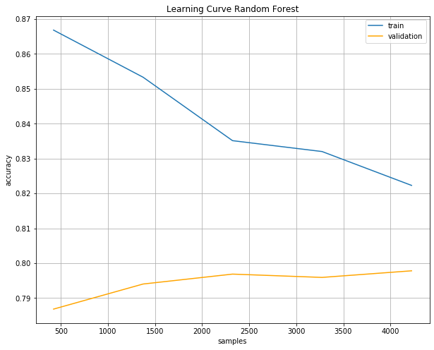

```python
from sklearn.model_selection import learning_curve

def plot_learning_curve(model,titles):
    sample_sizes, train_scores, val_scores = learning_curve(model, x_train, y_train, cv=5,
                                                         random_state=42,n_jobs=-1)
    fig, ax = plt.subplots(figsize=(10, 8))
    ax.plot(sample_sizes, train_scores.mean(axis=1), label='train')
    ax.plot(sample_sizes, val_scores.mean(axis=1), color='orange', label='validation')
    ax.set(xlabel='samples', ylabel='accuracy', title='Learning Curve {}'.format(titles))
    plt.grid()
    ax.legend()

plot_learning_curve(rf2, titles='Random Forest')
```

```python
from sklearn.model_selection import cross_validate

# cross validate
scores_rf2 = cross_validate(rf2, x_train, y_train, cv=5, return_train_score=True,return_estimator=False)
scores_rf2 = pd.DataFrame(scores_rf2)
scores_rf2
```

|  | fit_time | score_time | test_score | train_score |
| --- | --- | --- | --- | --- |
| 0 | 0.075829 | 0.110731 | 0.795648 | 0.824142 |
| 1 | 0.084771 | 0.106734 | 0.798486 | 0.821538 |
| 2 | 0.081874 | 0.110024 | 0.808712 | 0.820871 |
| 3 | 0.080785 | 0.109135 | 0.797348 | 0.819924 |
| 4 | 0.094748 | 0.105980 | 0.788826 | 0.826550 |

```python
print('Mean Test Score for Random Forest Classifier: ', scores_rf2['test_score'].mean())
print('Mean Train Score for Random Forest Classifier: ', scores_rf2['train_score'].mean())
```

```
Mean Test Score for Random Forest Classifier:  0.7978041412230154
Mean Train Score for Random Forest Classifier:  0.8226050960943384
```

```
[Text(33.0, 0.5, 'Truth'), Text(0.5, 15.0, 'Random Forest Prediction')]
```

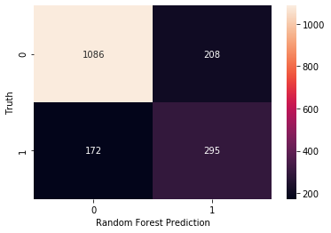

```python
from sklearn.metrics import confusion_matrix

ax = sns.heatmap(confusion_matrix(y_test, rf2_predictions), annot=True, fmt='d')
ax.set(xlabel='Random Forest Prediction', ylabel='Truth')
```

```python
from sklearn.metrics import classification_report

print(classification_report(y_test,rf2_predictions))
```

```
              precision    recall  f1-score   support

          No       0.86      0.84      0.85      1294
         Yes       0.59      0.63      0.61       467

    accuracy                           0.78      1761
   macro avg       0.72      0.74      0.73      1761
weighted avg       0.79      0.78      0.79      1761
```

## 2. Model Interpretation

```
Setting feature_perturbation = "tree_path_dependent" because no background data was given.
```

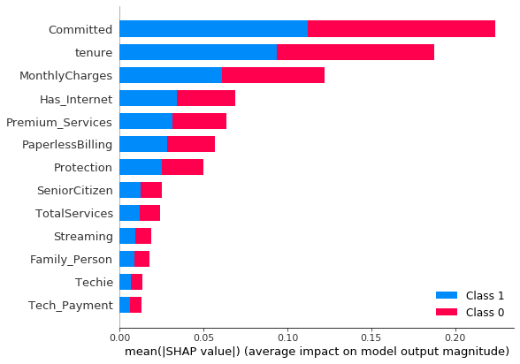

```python
import shap

# load JS visualization code to notebook
shap.initjs()

#Relative importance of each feature in determining target class probability
explainerRF = shap.TreeExplainer(rf2)
shap_values = explainerRF.shap_values(x_test)
shap.summary_plot(shap_values, x_test)
```

Feel free to try out how various features interact with each other segregated by churn status flag.

```python
# visualize the training set predictions similarity with respect to predictor variables
shap.force_plot(explainerRF.expected_value[0], shap_values[0], x)
```

[output not shown]

**Lift and cumulative charts**:  
1) **Lift** is a measure of the effectiveness of a predictive model calculated as the ratio between the results obtained with and without the predictive model.  
2) **Cumulative gains** and lift charts are visual aids for measuring model performance.  
3) Both charts consist of a curve and a baseline.

If we observe carefully, we can reach out to over 80% of churn customers with this random forest model if marketing budget targets 50% of its customers according to **cumulative gain curve**. With a random pick in absence of this model, we will be reaching out to 50% of churn customers.

**Lift** is calculated as the ratio of Cumulative Gains from classification and random models. If the average incidence of targets is 20%, so the lift is 2.5. Thus, the model allows addressing two-and-half times more targets for this group, compared with addressing without the model (randomly).

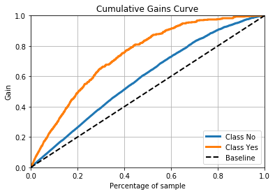

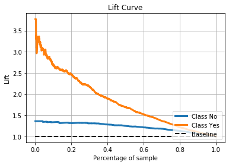

```python
import scikitplot as skplt

# Deriving Class probabilities
predicted_probabilities = rf2.predict_proba(x_test)
# Creating the plot
skplt.metrics.plot_cumulative_gain(y_test, predicted_probabilities)
skplt.metrics.plot_lift_curve(y_test, predicted_probabilities)
```

```
              precision    recall  f1-score   support

          No       0.86      0.88      0.87      5037
         Yes       0.68      0.64      0.66      2006

    accuracy                           0.81      7043
   macro avg       0.77      0.76      0.76      7043
weighted avg       0.81      0.81      0.81      7043
```

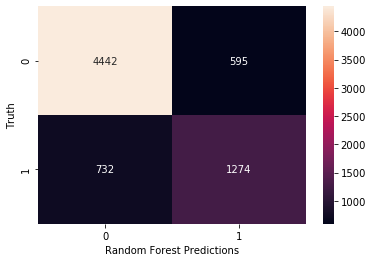

```python
churn_data['Churn_Predictions'] = rf2.predict(x)

ax = sns.heatmap(confusion_matrix(churn_data['Churn_Predictions'], churn_data['Churn']), annot=True, fmt='d')
ax.set(xlabel='Random Forest Predictions', ylabel='Truth')

print(classification_report(churn_data['Churn_Predictions'] , churn_data['Churn']))
```